# An exploration of PointNet's superiority over standard MLPs for point cloud classification

A point cloud is a collection of vertices in a three dimensional coordinate system. These vertices can, if large enough in number, resemble certain shapes: rectangles, spheres, cities or any other three dimensional object. An interesting problem, therefore, is to train a neural network which classifies a point cloud based on what it resembles.

Here we deal with a dataset of roughly $10000$ different point clouds, each with exactly $5000$ points and each resembling a car, plane or sofa. The ground truths of what these clouds resemble are known to us in the dataset and we want to train a model to predict which one of the three possibilities the clouds resemble.

A standard linear-layer model has weights in each layer which process the input features into the output features. These weights are allowed to depend on the particular feature, i.e. the first inputted point of the point cloud can be processed differently in a given layer than the last inputted point. This, of course, depends on the particular implementation, but it's generally strange from a human perspective: point clouds don't, after all, have a canonical ordering of points built into them, and even if they did, this ordering would be completely irrelevant to the question "what three dimensional object does this cloud of points resemble?".

PointNet, a model made exactly for this task, is a permutation-invariant model: it is designed so that each of its layers processes permutation-equivariantly, and the pooling layer collapses all of the previous features together in a permutation-invariant way. Therefore, while a traditional model might spend a lot of time and data points trying to "learn" that the order of the inputted points is irrelevant, PointNet can jump straight to recognizing the given shapes. In this notebook, we will compare PointNet's performance with a standard MLP's on the above-mentioned dataset.

We first import all of the necessary libraries.

```python
import torch
from torch.utils.data import Dataset, DataLoader
from sklearn.model_selection import train_test_split
import numpy as np
import os
import trimesh
import torch.nn as nn
import torch.nn.functional as F
from tqdm import tqdm

import plotly.graph_objects as go

import matplotlib.pyplot as plt
import pandas as pd
from IPython.display import display
from sklearn.metrics import confusion_matrix
```

We proceed by importing the dataset, which in this case is stored locally. The `classes` variable simply contains the triple `[car, plane, sofa]` and each point cloud stored in the dataset represents one of these three $3$-dimensional objects.

We store the full set of point clouds into `shapes_files` and their respective classes into `index_to_class`.

```python
dataset_dir = "data/pointclouds"
os.makedirs("data/checkpoints", exist_ok=True)
classes = os.listdir(dataset_dir)
class_to_index = dict((classes[i],i) for i in range(len(classes)))
index_to_class = dict((i, classes[i]) for i in range(len(classes)))
shapes_files = []
g_truth = []
for cls in classes:
    class_shapes = os.listdir(os.path.join(dataset_dir, cls))
    class_shapes = [os.path.join(dataset_dir, cls, x) for x in class_shapes]
    shapes_files += class_shapes
    g_truth += [class_to_index[cls]] * len(class_shapes)
class_indices = list(index_to_class.keys())
class_names = []
for class_index in class_indices:
    class_names.append(index_to_class[class_index])
```

```python
print(f"Dataset size: {len(shapes_files)}")
print(f"Number of cars: {g_truth.count(class_to_index["car"])}")
print(f"Number of planes: {g_truth.count(class_to_index["plane"])}")
print(f"Number of sofas: {g_truth.count(class_to_index["sofa"])}")
```

```
Dataset size: 10731
Number of cars: 3514
Number of planes: 4045
Number of sofas: 3172
```

We write a simple visualizer using the library `plotly`.

```python
def plot_pointcloud(points):
    fig = go.Figure(
        data=[
            go.Scatter3d(
                x=points[:,0],
                y=points[:,1],
                z=points[:,2],
                mode="markers",
                marker = dict(
                    size = 2,
                    opacity = 0.7
                )
            )
        ],
        layout=dict(
            scene=dict(
                xaxis=dict(visible=False),
                yaxis=dict(visible=False),
                zaxis=dict(visible=False)
            )
        )
    )
    fig.show()
```

We can now see any individual point cloud as a scatter plot. For example, below we see the scatter of a plane.

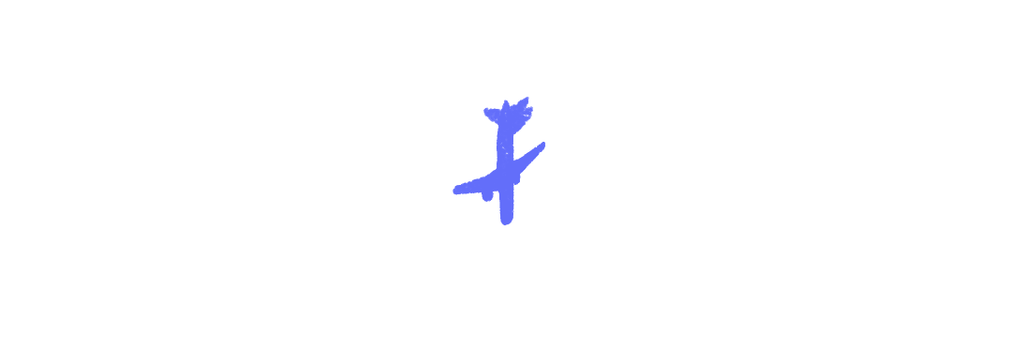

```
The number of points in this cloud is 5000.
```

```python
points = trimesh.load(shapes_files[4000]).vertices
plot_pointcloud(points)
print(f"The number of points in this cloud is {len(points)}.")
```

We now proceed to building the networks. We first construct the training, testing and validation splits...

```python
x_train, x_test, y_train, y_test = train_test_split(shapes_files, g_truth, train_size=0.5, random_state=0)
x_val, x_test, y_val, y_test = train_test_split(x_test, y_test, train_size=0.6, random_state=0)
```

...and then we build a simple dataset class and load the data.

```python
class ShapesDataset(Dataset):
    def __init__(self, files, classes):
        self.files = files
        self.classes = classes

    def __len__(self):
        return len(self.files)

    def __getitem__(self, i):
        f = self.files[i]
        cls = self.classes[i]
        pointcloud = torch.from_numpy(np.array(trimesh.load(f).vertices))
        rng = np.random.default_rng(i)
        indices = np.sort(rng.choice(pointcloud.shape[0],1024,replace=False))
        pointcloud = pointcloud[indices]
        return pointcloud, cls
```

Note that we've randomly (although deterministically!) selected $1024$ points out of the original $5000$ to train on. This is mainly to help with the training speeds, but the original PointNet model was actually described with $1024$ points in the original paper, so that gives further motivation.

```python
batch = 16

train_dataset = ShapesDataset(x_train, y_train)
val_dataset = ShapesDataset(x_val, y_val)
test_dataset = ShapesDataset(x_test, y_test)

train_loader = DataLoader(train_dataset, batch, shuffle=True, drop_last=True)
val_loader = DataLoader(val_dataset, batch, shuffle=False)
test_loader = DataLoader(test_dataset, batch, shuffle=False)
```

## PointNet

PointNet, published in 2017, was the first successful point cloud classification algorithm. It is permutation-invariant by design, so it is well-suited for the task of point cloud classification in that it doesn't implicitly "learn" the ordering of the inputted points. This specific type of permutation-invariant networks was described by DeepSets: a blueprint of permutation-invariant neural networks, which was developed some time after PointNet itself.

Neural networks of the DeepSets blueprint are of the following form:

$$f(X) = \phi\left( \bigoplus_{i \in \{1, 2, \dots, k\}} \psi(x_i) \right),$$

where $X = (x_1, x_2, \dots, x_k)$ is the initial vector input (e.g. a vector of points in a point cloud), $f(X)$ is the final vector of logits (in this case, three logits corresponding to the three possible shapes), $\phi$ and $\psi$ are learnable functions (i.e. they are a composition of a number of layers) and $\bigoplus$ is some operation invariant to permutation of its inputs (e.g. $\bigoplus \in \{\sum, \mathrm{avg}, \mathrm{max}, \mathrm{min}, \dots\}$).

The following diagram illustrates the architecture of PointNet and it marks the corresponding elements of the DeepSets blueprint.

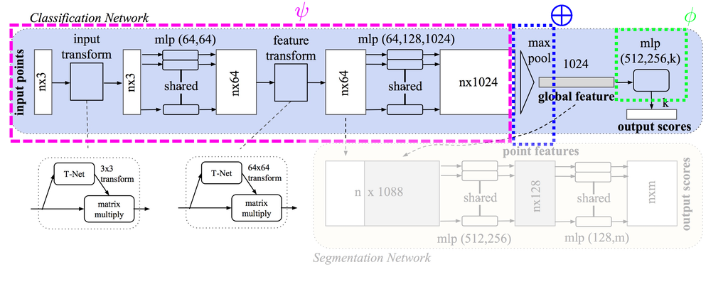

Note that we don't use the greyed-out segmentation network. Also, the T-Nets we talk about below slightly complicate the overall DeepSets decomposition, but the intuitive idea is the same.

In the above diagram, we see that there is a second, smaller version of the larger PointNet — it's T-Net, which is a regression network architectually similar to PointNet, but much simpler. T-Net also follows the DeepSets blueprint, as we can see on this diagram of the T-Net architecture (in this case, we depict the $3 \times 3$ output, but the $64 \times 64$ one is very similar).

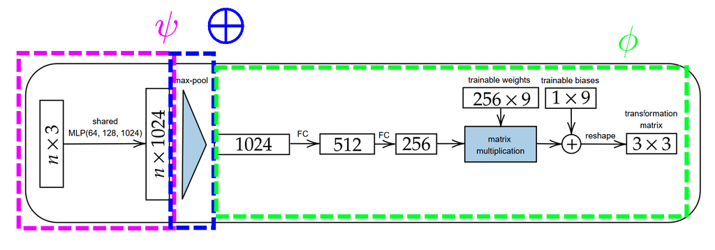

We begin by implementing T-Net.

```python
class TNet(nn.Module):
    def __init__(self, input_dim):
        super().__init__()
        self.matrix_dim = input_dim
        self.fc1 = nn.Linear(input_dim, 64)
        self.bn1 = nn.BatchNorm1d(64)

        self.fc2 = nn.Linear(64,128)
        self.bn2 = nn.BatchNorm1d(128)

        self.fc3 = nn.Linear(128,1024)
        self.bn3 = nn.BatchNorm1d(1024)

        self.fc4 = nn.Linear(1024,512)
        self.bn4 = nn.BatchNorm1d(512)

        self.fc5 = nn.Linear(512,256)
        self.bn5 = nn.BatchNorm1d(256)

        self.output_layer = nn.Linear(256,self.matrix_dim**2)
        nn.init.zeros_(self.output_layer.weight)
        with torch.no_grad():
            self.output_layer.bias.copy_(torch.eye(self.matrix_dim).reshape(-1))
    def forward(self, x):
        fc1_out = F.relu(self.bn1(self.fc1(x).transpose(1,2))).transpose(1,2)
        fc2_out = F.relu(self.bn2(self.fc2(fc1_out).transpose(1,2))).transpose(1,2)
        fc3_out = F.relu(self.bn3(self.fc3(fc2_out).transpose(1,2))).transpose(1,2)

        maxpool_out = torch.max(fc3_out, dim = 1)[0]

        fc4_out = F.relu(self.bn4(self.fc4(maxpool_out)))
        fc5_out = F.relu(self.bn5(self.fc5(fc4_out)))
        matrix_out = self.output_layer(fc5_out).reshape(-1,self.matrix_dim,self.matrix_dim)

        return matrix_out
```

Finally, we implement PointNet. It is almost identical to the diagram above, except for a very slight simplification: we drop the $64 \rightarrow 64$ intermediate layer after the feature transform.

```python
class PointNet(nn.Module):
    def __init__(self):
        super().__init__()

        self.t_net1 = TNet(3)

        self.fc1 = nn.Linear(3, 64)
        self.bn1 = nn.BatchNorm1d(64)

        self.fc2 = nn.Linear(64,64)
        self.bn2 = nn.BatchNorm1d(64)

        self.t_net2 = TNet(64)

        self.fc3 = nn.Linear(64,128)
        self.bn3 = nn.BatchNorm1d(128)

        self.fc4 = nn.Linear(128,1024)
        self.bn4 = nn.BatchNorm1d(1024)

        self.fc5 = nn.Linear(1024,512)
        self.bn5 = nn.BatchNorm1d(512)

        self.fc6 = nn.Linear(512,256)
        self.bn6 = nn.BatchNorm1d(256)
        self.dropout = nn.Dropout(p = 0.3)

        self.output_layer = nn.Linear(256,3)
    def forward(self, x):
        t1 = self.t_net1(x)
        t1_v = torch.bmm(t1, x.transpose(1,2)).transpose(1,2)

        fc1_out = F.relu(self.bn1(self.fc1(t1_v).transpose(1,2))).transpose(1,2)
        fc2_out = F.relu(self.bn2(self.fc2(fc1_out).transpose(1,2))).transpose(1,2)

        t2 = self.t_net2(fc2_out)
        t2_v = torch.bmm(t2, fc2_out.transpose(1,2)).transpose(1,2)

        fc3_out = F.relu(self.bn3(self.fc3(t2_v).transpose(1,2))).transpose(1,2)
        fc4_out = F.relu(self.bn4(self.fc4(fc3_out).transpose(1,2))).transpose(1,2)

        maxpool_out = torch.max(fc4_out, dim = 1)[0]

        fc5_out = F.relu(self.bn5(self.fc5(maxpool_out)))
        fc6_out = self.dropout(F.relu(self.bn6(self.fc6(fc5_out))))

        out = self.output_layer(fc6_out)

        return out, t1, t2
```

PointNet uses a loss function defined as:

$$L = L_{\mathrm{cls}} + \lambda L_{\mathrm{reg}},$$

where $L_{\mathrm{cls}}$ represents the cross-entropy classification loss, averaged over the batch, and $L_{\mathrm{reg}}$ is a regularization term applied to the predicted $64 \times 64$ feature transformation matrices to encourage orthogonality. Intuitively, T-Net is supposed to help with the "geometric" transformation of the feature space, so it isn't supposed to significantly deform the given shape. Therefore, its predicted matrix should be roughly orthogonal, so that they can preserve the "geometric" properties of the feature space, i.e. the lengths and inner products.

The regularization loss is formally defined as:

$$L_{\mathrm{reg}} = \sum_{b = 1}^{B} \left\| \left( T_{64\times64}^{(b)} \right)^T T_{64\times64}^{(b)} - I_{64\times64} \right\|_F^2$$

Here:

- $B$ is the batch size, and $T_{64\times64}^{(b)}$ is the feature transformation matrix predicted for the $b$-th point cloud.
- $\|\cdot\|_F$ denotes the Frobenius norm.
- $I_{64\times64}$ is the $64\times64$ identity matrix.
- $\lambda$ is a parameter which balances the classification and regularization losses; in our case, it's set to $0.0005$.

We can now implement the following functions, which will then perform the training and testing of PointNet.

```python
def train_pointnet(model, train_loader, val_loader, ckpt_path):
    if torch.cuda.is_available():
        device = ("cuda")
    else:
        device = ("cpu")
    model = model.to(device)

    optimizer = torch.optim.Adam(model.parameters(), lr=0.001)
    crit = nn.CrossEntropyLoss()

    id_64x64 = torch.eye(64).unsqueeze(0).to(device)

    history = {
        "train_accuracy": [],
        "val_accuracy": [],
        "train_loss": [],
        "val_loss": [],
    }

    num_epochs = 10
    for epoch in range(num_epochs):
        model.train()
        train_cls_loss = 0.0
        train_reg_loss = 0.0
        correct_pred = 0
        total = 0

        for data, labels in tqdm(train_loader, desc=f"Epoch {epoch+1}/{num_epochs}"):
            optimizer.zero_grad()

            data = data.to(device).float()
            labels = labels.to(device)

            logits, t1, t2 = model(data)

            cls_loss = crit(logits, labels)
            reg_loss = torch.sum((torch.bmm(t2.transpose(1,2), t2) - id_64x64)**2)
            loss = cls_loss + 5e-4 * reg_loss
            loss.backward()

            optimizer.step()

            train_cls_loss += cls_loss.item() * batch
            train_reg_loss += reg_loss.item()

            predicted = torch.max(logits, 1)[1]
            correct_pred += (predicted == labels).sum().item()
            total += batch

        train_accuracy = 100 * correct_pred / total

        print(f"Epoch {epoch+1}/{num_epochs}")
        print(f"Training cross-entropy loss: {train_cls_loss/total:.4f}")
        print(f"Training regularization loss: {train_reg_loss/total:.4f}")
        print(f"Training accuracy: {train_accuracy:.2f}%")

        model.eval()
        val_cls_loss = 0.0
        val_reg_loss = 0.0
        correct_val = 0
        total_val = 0

        with torch.no_grad():
            for data, labels in val_loader:
                data = data.to(device).float()
                labels = labels.to(device)

                logits, t1, t2 = model(data)
                cls_loss = crit(logits, labels)
                reg_loss = torch.sum((torch.bmm(t2.transpose(1,2), t2) - id_64x64)**2)

                val_cls_loss += cls_loss.item() * data.shape[0]
                val_reg_loss += reg_loss.item()

                predicted = torch.max(logits, 1)[1]
                correct_val += (predicted == labels).sum().item()
                total_val += data.shape[0]

        val_accuracy = 100 * correct_val / total_val

        history["train_accuracy"].append(train_accuracy)
        history["val_accuracy"].append(val_accuracy)
        history["train_loss"].append(train_cls_loss/total)
        history["val_loss"].append(val_cls_loss/total)

        print(f"Epoch {epoch+1}/{num_epochs}")
        print(f"Validation cross-entropy loss: {val_cls_loss/len(val_dataset):.4f}")
        print(f"Validation regularization loss: {val_reg_loss/len(val_dataset):.4f}")
        print(f"Validation accuracy: {val_accuracy:.2f}%")

    state_dict = {"model_state_dict": model.state_dict(), "optimizer_state_dict": optimizer.state_dict(), "history": history}
    torch.save(state_dict, ckpt_path)
```

```python
def test_pointnet(model, test_loader, ckpt_path):
    if torch.cuda.is_available():
        device = ("cuda")
    else:
        device = ("cpu")
    model = model.to(device)

    crit = nn.CrossEntropyLoss()

    state_dict = torch.load(ckpt_path, map_location=device)
    model.load_state_dict(state_dict["model_state_dict"])
    model.eval()

    test_loss = 0.0
    correct_test = 0
    with torch.no_grad():
        for data, labels in test_loader:
            data, labels = data.to(device).float(), labels.to(device)

            logits = model(data)[0]
            loss = crit(logits, labels)

            test_loss += loss.item() * data.shape[0]
            predicted = torch.max(logits, 1)[1]
            correct_test += (predicted == labels).sum().item()

    test_accuracy = 100 * correct_test / len(test_dataset)
    print(f"Test loss: {test_loss/len(test_dataset):.4f}")
    print(f"Test accuracy: {test_accuracy:.2f}%")
```

Let's now train and test PointNet.

```python
if torch.cuda.is_available():
    device = ("cuda")
else:
    device = ("cpu")
model = PointNet().to(device)
train_pointnet(model, train_loader=train_loader, val_loader=val_loader, ckpt_path="data/checkpoints/pointnet.pth")
```

```
Training cross-entropy loss: 0.2182
Training regularization loss: 28.7045
Training accuracy: 93.82%
Validation cross-entropy loss: 3.0545
Validation regularization loss: 1785.7676
Validation accuracy: 56.76%
```

```
Training cross-entropy loss: 0.1502
Training regularization loss: 6.2730
Training accuracy: 95.41%
Validation cross-entropy loss: 0.0334
Validation regularization loss: 1.7888
Validation accuracy: 99.16%
```

```
Training cross-entropy loss: 0.0664
Training regularization loss: 1.0640
Training accuracy: 98.17%
Validation cross-entropy loss: 0.0321
Validation regularization loss: 0.4739
Validation accuracy: 99.16%
```

```
Training cross-entropy loss: 0.0546
Training regularization loss: 0.6421
Training accuracy: 98.62%
Validation cross-entropy loss: 0.0353
Validation regularization loss: 0.2522
Validation accuracy: 99.29%
```

```
Training cross-entropy loss: 0.1398
Training regularization loss: 14.5137
Training accuracy: 95.69%
Validation cross-entropy loss: 0.0471
Validation regularization loss: 0.2956
Validation accuracy: 98.73%
```

```
Training cross-entropy loss: 0.0830
Training regularization loss: 0.8293
Training accuracy: 97.69%
Validation cross-entropy loss: 0.0460
Validation regularization loss: 0.1025
Validation accuracy: 98.79%
```

```
Training cross-entropy loss: 0.0692
Training regularization loss: 1.0157
Training accuracy: 98.23%
Validation cross-entropy loss: 0.0676
Validation regularization loss: 0.0864
Validation accuracy: 98.76%
```

```
Training cross-entropy loss: 0.0466
Training regularization loss: 0.2766
Training accuracy: 98.82%
Validation cross-entropy loss: 0.0260
Validation regularization loss: 0.0941
Validation accuracy: 99.29%
```

```
Training cross-entropy loss: 0.0466
Training regularization loss: 0.5691
Training accuracy: 98.81%
Validation cross-entropy loss: 0.0446
Validation regularization loss: 0.1039
Validation accuracy: 99.01%
```

```
Training cross-entropy loss: 0.0663
Training regularization loss: 0.9984
Training accuracy: 98.28%
Validation cross-entropy loss: 0.0254
Validation regularization loss: 0.1103
Validation accuracy: 99.50%
```

```python
test_pointnet(model, test_loader=test_loader, ckpt_path="data/checkpoints/pointnet.pth")
```

```
Test loss: 0.0210
Test accuracy: 99.63%
```

We can use it to try to predict the class of the same example we saw at the beginning. Since PointNet's learned layers don't actually depend on the number of points in the input, we can simply input the original $5000$-point cloud.

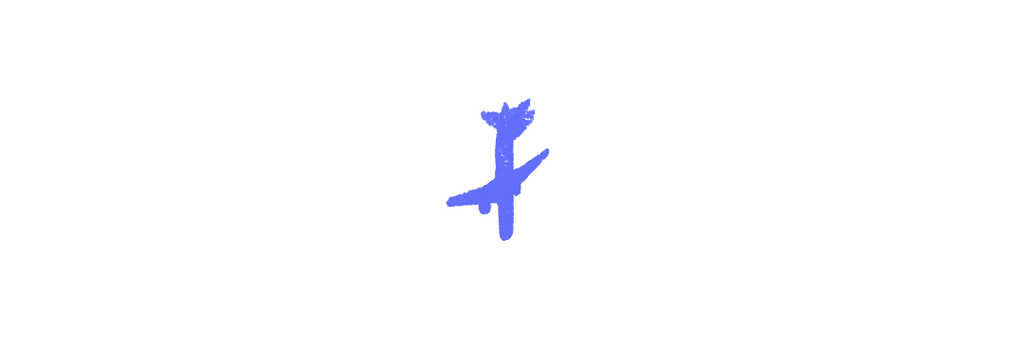

```
Predicted class: plane
Ground truth: plane
```

```python
points_tensor = torch.from_numpy(np.array(points)).unsqueeze(0).to(device).float()

with torch.no_grad():
    logits = model(points_tensor)[0]

prediction = index_to_class[logits.argmax(-1).item()]

plot_pointcloud(points)

print(f"Predicted class: {prediction}")
print(f"Ground truth: {index_to_class[g_truth[4000]]}")
```

## A noninvariant MLP

Now we write a fairly standard permutation-noninvariant MLP. PointNet should theoretically speaking be better suited for this task on a dataset such as this one.

This MLP has the first few layers identical to PointNet's, so they are similarly permutation-equivariant. The final layer, however, is applied after the features are flattened, so each feature is then processed independently by the `output_layer`.

```python
class StandardMLP(nn.Module):
    def __init__(self):
        super().__init__()

        self.fc1 = nn.Linear(3, 64)
        self.bn1 = nn.BatchNorm1d(64)

        self.fc2 = nn.Linear(64,64)
        self.bn2 = nn.BatchNorm1d(64)

        self.fc3 = nn.Linear(64,128)
        self.bn3 = nn.BatchNorm1d(128)

        self.fc4 = nn.Linear(128,1024)
        self.bn4 = nn.BatchNorm1d(1024)

        self.fc5 = nn.Linear(1024,512)
        self.bn5 = nn.BatchNorm1d(512)

        self.fc6 = nn.Linear(512,779)
        self.bn6 = nn.BatchNorm1d(779)

        self.output_layer = nn.Linear(779*1024,3)

    def forward(self, x):

        fc1_out = F.relu(self.bn1(self.fc1(x).transpose(1,2))).transpose(1,2)
        fc2_out = F.relu(self.bn2(self.fc2(fc1_out).transpose(1,2))).transpose(1,2)
        fc3_out = F.relu(self.bn3(self.fc3(fc2_out).transpose(1,2))).transpose(1,2)
        fc4_out = F.relu(self.bn4(self.fc4(fc3_out).transpose(1,2))).transpose(1,2)
        fc5_out = F.relu(self.bn5(self.fc5(fc4_out).transpose(1,2))).transpose(1,2)
        fc6_out = F.relu(self.bn6(self.fc6(fc5_out).transpose(1,2))).transpose(1,2)

        B = fc6_out.shape[0]
        fc6_out = fc6_out.reshape(B, -1)

        out = self.output_layer(fc6_out)

        return out
```

The at-first curious number $779$ of output features in the last linear layer can be explained by comparing the parameters of the PointNet and MLP models.

We've kept the dimensions of the first five layers in both models identical: both PointNet and the MLP have layers of the form

$$3 \longrightarrow 64 \longrightarrow 64 \longrightarrow 128 \longrightarrow 1024 \longrightarrow 512.$$

We can calculate the combined parameter count of these layers as so:

$$\begin{equation} \begin{split} P_{\mathrm{1-5}} &=64(3+1)+64(64+1)+128(64+1)\\ &+1024(128+1)+512(1024+1)\\ &+2(64+64+128+1024+512)\\ &=673216. \end{split} \notag \end{equation}$$

Note that we've also accounted for the BatchNorm parameters here. PointNet then contains the layers $512 \rightarrow 256 \rightarrow 3$ with a BatchNorm on the $256$ features, giving another

$$256(512+1)+2(256)+3(256+1) = 132611$$

parameters. We also have to account for the two T-Nets, which are of the form

$$k \longrightarrow 64 \longrightarrow 128 \longrightarrow 1024 \longrightarrow 512 \longrightarrow 256 \longrightarrow k^2,$$

where $k \in \{3, 64\}$. This gives another $803081 + 1857344$, giving PointNet a total of $3466252$ parameters.

At the end of the noninvariant MLP, we have a shared $512 \rightarrow 779$, a flatten operation, and then a $(1024 \cdot 779) \rightarrow 3)$, so it has a total of $P_{\mathrm{1-5}} + 779(512 + 1) + 2 \cdot 779 + 3(1024 \cdot 779 + 1) = 3467492 \approx 3466252$ parameters.

We see that we have constructed the models to have a roughly equal number of parameters, which will allow us to more directly compare the quality and efficiency of each model.

Here we have the train and test functions for this MLP. They are essentially just slightly simpler versions of the train and test functions for PointNet.

```python
def train_mlp(model, train_loader, val_loader, ckpt_path):
    if torch.cuda.is_available():
        device = ("cuda")
    else:
        device = ("cpu")
    model = model.to(device)

    optimizer = torch.optim.Adam(model.parameters(), lr=0.001)
    crit = nn.CrossEntropyLoss()

    history = {
        "train_accuracy": [],
        "val_accuracy": [],
        "train_loss": [],
        "val_loss": [],
    }

    num_epochs = 10
    for epoch in range(num_epochs):
        model.train()
        train_cls_loss = 0.0
        correct_pred = 0
        total = 0

        for data, labels in tqdm(train_loader, desc=f"Epoch {epoch+1}/{num_epochs}"):
            optimizer.zero_grad()

            data = data.to(device).float()
            labels = labels.to(device)

            logits = model(data)

            cls_loss = crit(logits, labels)
            loss = cls_loss
            loss.backward()

            optimizer.step()

            train_cls_loss += cls_loss.item() * batch

            predicted = torch.max(logits, 1)[1]
            correct_pred += (predicted == labels).sum().item()
            total += batch

        train_accuracy = 100 * correct_pred / total

        print(f"Epoch {epoch+1}/{num_epochs}")
        print(f"Training cross-entropy loss: {train_cls_loss/total:.4f}")
        print(f"Training accuracy: {train_accuracy:.2f}%")

        model.eval()
        val_cls_loss = 0.0
        correct_val = 0
        total_val = 0

        with torch.no_grad():
            for data, labels in val_loader:
                data = data.to(device).float()
                labels = labels.to(device)

                logits = model(data)
                cls_loss = crit(logits, labels)

                val_cls_loss += cls_loss.item() * data.shape[0]

                predicted = torch.max(logits, 1)[1]
                correct_val += (predicted == labels).sum().item()
                total_val += data.shape[0]

        val_accuracy = 100 * correct_val / total_val

        history["train_accuracy"].append(train_accuracy)
        history["val_accuracy"].append(val_accuracy)
        history["train_loss"].append(train_cls_loss/total)
        history["val_loss"].append(val_cls_loss/len(val_dataset))

        print(f"Epoch {epoch+1}/{num_epochs}")
        print(f"Validation cross-entropy loss: {val_cls_loss/len(val_dataset):.4f}")
        print(f"Validation accuracy: {val_accuracy:.2f}%")

    state_dict = {"model_state_dict": model.state_dict(), "optimizer_state_dict": optimizer.state_dict(), "history": history}
    torch.save(state_dict, ckpt_path)
```

```python
def test_mlp(model, test_loader, ckpt_path):
    if torch.cuda.is_available():
        device = ("cuda")
    else:
        device = ("cpu")
    model = model.to(device)

    crit = nn.CrossEntropyLoss()

    state_dict = torch.load(ckpt_path, map_location=device)
    model.load_state_dict(state_dict["model_state_dict"])
    model.eval()

    test_loss = 0.0
    correct_test = 0
    with torch.no_grad():
        for data, labels in test_loader:
            data, labels = data.to(device).float(), labels.to(device)

            logits = model(data)
            loss = crit(logits, labels)

            test_loss += loss.item() * data.shape[0]
            predicted = torch.max(logits, 1)[1]
            correct_test += (predicted == labels).sum().item()

    test_accuracy = 100 * correct_test / len(test_dataset)
    print(f"Test loss: {test_loss/len(test_dataset):.4f}")
    print(f"Test accuracy: {test_accuracy:.2f}%")
```

Finally, we train and test the MLP.

```python
model = StandardMLP()
train_mlp(model, train_loader = train_loader, val_loader = val_loader, ckpt_path="data/checkpoints/mlp.pth")
```

```
Training cross-entropy loss: 10.8166
Training accuracy: 89.94%
Validation cross-entropy loss: 3.0306
Validation accuracy: 97.33%
```

```
Training cross-entropy loss: 4.1383
Training accuracy: 95.07%
Validation cross-entropy loss: 2.3384
Validation accuracy: 97.98%
```

```
Training cross-entropy loss: 4.2105
Training accuracy: 95.60%
Validation cross-entropy loss: 2.7882
Validation accuracy: 96.37%
```

```
Training cross-entropy loss: 1.4343
Training accuracy: 97.03%
Validation cross-entropy loss: 1.9151
Validation accuracy: 98.54%
```

```
Training cross-entropy loss: 0.8956
Training accuracy: 97.80%
Validation cross-entropy loss: 1.6227
Validation accuracy: 97.45%
```

```
Training cross-entropy loss: 0.5913
Training accuracy: 98.47%
Validation cross-entropy loss: 1.9246
Validation accuracy: 97.55%
```

```
Training cross-entropy loss: 0.9357
Training accuracy: 97.57%
Validation cross-entropy loss: 1.6033
Validation accuracy: 97.98%
```

```
Training cross-entropy loss: 0.4776
Training accuracy: 98.64%
Validation cross-entropy loss: 1.6575
Validation accuracy: 97.64%
```

```
Training cross-entropy loss: 0.2452
Training accuracy: 99.09%
Validation cross-entropy loss: 1.1341
Validation accuracy: 98.32%
```

```
Training cross-entropy loss: 0.5152
Training accuracy: 98.47%
Validation cross-entropy loss: 1.2942
Validation accuracy: 97.51%
```

```python
test_mlp(model, test_loader=test_loader, ckpt_path="data/checkpoints/mlp.pth")
```

```
Test loss: 1.7418
Test accuracy: 97.21%
```

## PointNet vs. a standard MLP

We load the training history (the loss and accuracy for each epoch) we've kept track of while training the models.

```python
pointnet_checkpoint = torch.load("data/checkpoints/pointnet.pth", map_location="cpu")
pointnet_history = pointnet_checkpoint["history"]

mlp_checkpoint = torch.load("data/checkpoints/mlp.pth", map_location="cpu")
mlp_history = mlp_checkpoint["history"]

epochs = list(range(1, len(pointnet_history["train_accuracy"]) + 1))

histories = {
    "PointNet": pointnet_history,
    "MLP": mlp_history,
}
```

We now generate some diagrams to showcase their performance throughout the training.

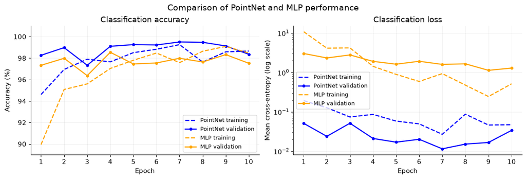

```python
plt.rcParams.update({
    "font.size": 11,
    "axes.spines.top": False,
    "axes.spines.right": False
})

fig, axes = plt.subplots(1, 2, figsize=(12, 4), constrained_layout=True)
colors = {"PointNet": "blue", "MLP": "orange"}

for name, history in histories.items():
    axes[0].plot(epochs, history["train_accuracy"], color=colors[name], linestyle="--", linewidth=1.8, label= name + " training")
    axes[0].plot(epochs, history["val_accuracy"], color=colors[name], marker="o", markersize=4, linewidth=1.8, label= name + " validation")
    axes[1].plot(epochs, history["train_loss"], color=colors[name], linestyle="--", linewidth=1.8, label= name + " training")
    axes[1].plot(epochs, history["val_loss"], color=colors[name], marker="o", markersize=4, linewidth=1.8, label= name + " validation")

for ax in axes:
    ax.set_xlabel("Epoch")
    ax.set_xticks(epochs)
    ax.grid(alpha=0.2)

axes[0].set_title("Classification accuracy")
axes[0].set_ylabel("Accuracy (%)")
axes[0].set_ylim(89, 101)
axes[0].legend(loc="lower right", fontsize=9)

axes[1].set_title("Classification loss")
axes[1].set_ylabel("Mean cross-entropy (log scale)")
axes[1].set_yscale("log")
axes[1].legend(loc="center left", fontsize=9)

fig.suptitle("Comparison of PointNet and MLP performance", fontsize=14)

fig.savefig("images/pointnet_mlp_learning_curves.png", dpi=180, bbox_inches="tight", facecolor="white")
plt.show()
```

Next, we will construct so-called "confusion matrices" (they showcase, for each possible class, how often the model correctly predicted the class and how often it incorrectly predicted it) and summary tables for each of the models. For this, we will first need to evaluate the models, which we do below.

```python
def evaluate_model(model, test_loader, ckpt_path, is_pointnet):
    if torch.cuda.is_available():
        device = ("cuda")
    else:
        device = ("cpu")
    model = model.to(device)

    crit = nn.CrossEntropyLoss()

    state_dict = torch.load(ckpt_path, map_location=device)
    model.load_state_dict(state_dict["model_state_dict"])
    model.eval()

    test_loss = 0.0
    correct_test = 0
    total = 0
    true_labels = []
    predicted_labels = []

    with torch.no_grad():
        for data, labels in test_loader:
            data = data.to(device).float()
            labels = labels.to(device)

            if is_pointnet:
                logits = model(data)[0]
            else:
                logits = model(data)

            loss = crit(logits, labels)

            test_loss += loss.item() * data.shape[0]
            predicted = torch.max(logits, 1)[1]
            correct_test += (predicted == labels).sum().item()
            total += data.shape[0]

            true_labels.extend(labels.cpu().tolist())
            predicted_labels.extend(predicted.cpu().tolist())

    test_accuracy = 100 * correct_test / total
    print(f"Test loss: {test_loss/total:.4f}")
    print(f"Test accuracy: {test_accuracy:.2f}%")

    parameters = 0
    for parameter in model.parameters():
        if parameter.requires_grad:
            parameters += parameter.numel()

    return {
        "loss": test_loss/total,
        "accuracy": test_accuracy,
        "parameters": parameters,
        "true_labels": true_labels,
        "predicted_labels": predicted_labels,
    }
```

We evaluate the models using this function.

```python
print("PointNet:")
pointnet_results = evaluate_model(PointNet(), test_loader, "data/checkpoints/pointnet.pth", is_pointnet=True)
print("Standard MLP:")
mlp_results = evaluate_model(StandardMLP(), test_loader, "data/checkpoints/mlp.pth", is_pointnet=False)
```

```
PointNet:
Test loss: 0.0210
Test accuracy: 99.63%
Standard MLP:
Test loss: 1.7418
Test accuracy: 97.21%
```

Finally, we construct the tables and matrices.

```python
summary = pd.DataFrame([
    {"Model": "PointNet",
     "Parameters": pointnet_results["parameters"],
     "Loss": pointnet_results["loss"],
     "Accuracy (%)": pointnet_results["accuracy"]},
    {"Model": "MLP",
     "Parameters": mlp_results["parameters"],
     "Loss": mlp_results["loss"],
     "Accuracy (%)": mlp_results["accuracy"]},
])
summary = summary.set_index("Model")
display(summary.round({"Loss": 4, "Accuracy (%)": 2}))

accuracy_difference = pointnet_results["accuracy"] - mlp_results["accuracy"]
print(f"Absolute difference in test accuracy: {accuracy_difference:.2f}%")

results_by_model = {"PointNet": pointnet_results, "MLP": mlp_results}
confusion_tables = {}

for name, results in results_by_model.items():
    matrix = confusion_matrix(results["true_labels"], results["predicted_labels"], labels=class_indices)
    table = pd.DataFrame(matrix, index=class_names, columns=class_names)
    table.index.name = "True class"
    table.columns.name = "Predicted class"
    confusion_tables[name] = table

    print(f"\n{name} confusion matrix (counts)")
    display(table)
```

| Model | Parameters | Loss | Accuracy (%) |
| --- | --- | --- | --- |
| PointNet | 3466252 | 0.0210 | 99.63 |
| MLP | 3467492 | 1.7418 | 97.21 |

```
Absolute difference in test accuracy: 2.42%

PointNet confusion matrix (counts)
```

| Predicted class True class | car | plane | sofa |
| --- | --- | --- | --- |
| car | 702 | 1 | 1 |
| plane | 3 | 807 | 0 |
| sofa | 2 | 1 | 630 |

```
MLP confusion matrix (counts)
```

| Predicted class True class | car | plane | sofa |
| --- | --- | --- | --- |
| car | 677 | 20 | 7 |
| plane | 19 | 781 | 10 |
| sofa | 3 | 1 | 629 |

The MLP has a clear outlier here: it very often misclassifies planes as cars or sofas, while the PointNet model has no outstanding error rate in any of the cells. If we for whatever reason wanted to pick out all the cars from this dataset, in the case of PointNet, we would get a very accurate result, with only a few incorrectly included or excluded results. But for the MLP, we would get a sizeable amount of planes in the final list of cars. This shows a significant practical benefit to the PointNet model.

## Training on an augmented dataset

The MLP's big disadvantage in this comparison is that it believes the order of the inputted vertices is somehow significant. Let us explore this phenomenon a little further: firstly, we will permute the vertices of each point cloud and then test the models' performances on those permuted vertices.

Here we have the permuted datasets...

```python
class ShapesDatasetPermuted(Dataset):
    def __init__(self, files, classes):
        self.files = files
        self.classes = classes

    def __len__(self):
        return len(self.files)

    def __getitem__(self, i):
        f = self.files[i]
        cls = self.classes[i]
        pointcloud = torch.from_numpy(np.array(trimesh.load(f).vertices))
        rng = np.random.default_rng(i)
        indices = np.sort(rng.choice(pointcloud.shape[0],1024,replace=False))
        pointcloud = pointcloud[indices]
        perm = torch.randperm(pointcloud.shape[0])
        return pointcloud[perm], cls
```

```python
train_dataset_perm = ShapesDatasetPermuted(x_train, y_train)
val_dataset_perm = ShapesDatasetPermuted(x_val, y_val)
test_dataset_perm = ShapesDatasetPermuted(x_test, y_test)

train_loader_perm = DataLoader(train_dataset_perm, batch, shuffle=True, drop_last=True)
val_loader_perm = DataLoader(val_dataset_perm, batch, shuffle=False)
test_loader_perm = DataLoader(test_dataset_perm, batch, shuffle=False)
```

...and now we test the models.

```python
print("PointNet on permuted data:")
pointnet_results_perm = evaluate_model(PointNet(), test_loader_perm, "data/checkpoints/pointnet.pth", is_pointnet=True)
print("Standard MLP on permuted data:")
mlp_results_perm = evaluate_model(StandardMLP(), test_loader_perm, "data/checkpoints/mlp.pth", is_pointnet=False)
```

```
PointNet on permuted data:
Test loss: 0.0210
Test accuracy: 99.63%
Standard MLP on permuted data:
Test loss: 1.6262
Test accuracy: 97.16%
```

The loss and accuracy of PointNet had to have stayed the same: it is completely invariant to permutations of the input vector. The MLP's accuracy expectedly decreased, although slightly. However, its loss also stayed quite high, which suggests the model is, like before, still correctly classifying for the most part, but with less-than-ideal probability distributions. Clearly, PointNet is to be preferred with respect to this test.

An even more interesting question arises out of this result: the MLP could presumably learn that the order of the inputted vertices is unimportant, just as it can learn any other feature of the point clouds. We could therefore try to retrain the MLP on this permuted dataset in an attempt to increase its accuracy. This should, speaking relatively vaguely and conceptually, allow it to "learn" that the order of the points doesn't matter too much in this dataset.

```python
model = StandardMLP()
train_mlp(model, train_loader = train_loader_perm, val_loader = val_loader_perm, ckpt_path="data/checkpoints/mlp_perm.pth")
```

```
Training cross-entropy loss: 15.8319
Training accuracy: 89.94%
Validation cross-entropy loss: 4.3927
Validation accuracy: 96.24%
```

```
Training cross-entropy loss: 6.4334
Training accuracy: 94.05%
Validation cross-entropy loss: 6.8948
Validation accuracy: 96.46%
```

```
Training cross-entropy loss: 5.3795
Training accuracy: 94.83%
Validation cross-entropy loss: 4.1095
Validation accuracy: 97.33%
```

```
Training cross-entropy loss: 3.0408
Training accuracy: 96.18%
Validation cross-entropy loss: 2.0052
Validation accuracy: 97.42%
```

```
Training cross-entropy loss: 3.1139
Training accuracy: 95.73%
Validation cross-entropy loss: 1.5511
Validation accuracy: 97.61%
```

```
Training cross-entropy loss: 3.0875
Training accuracy: 96.38%
Validation cross-entropy loss: 1.8480
Validation accuracy: 97.64%
```

```
Training cross-entropy loss: 2.1495
Training accuracy: 96.55%
Validation cross-entropy loss: 1.0755
Validation accuracy: 97.92%
```

```
Training cross-entropy loss: 2.0596
Training accuracy: 96.59%
Validation cross-entropy loss: 1.1423
Validation accuracy: 98.20%
```

```
Training cross-entropy loss: 1.7376
Training accuracy: 96.72%
Validation cross-entropy loss: 1.4074
Validation accuracy: 97.67%
```

```
Training cross-entropy loss: 1.4971
Training accuracy: 97.11%
Validation cross-entropy loss: 1.0766
Validation accuracy: 97.95%
```

We can now test this new version as well:

```python
print("Standard MLP trained on permuted data:")
mlp_aug_results_perm = evaluate_model(StandardMLP(), test_loader_perm, "data/checkpoints/mlp_perm.pth", is_pointnet=False)
```

```
Standard MLP trained on permuted data:
Test loss: 0.8576
Test accuracy: 98.09%
```

This did significantly improve the results. There are many possible explanations; the simplest one is that the model managed to learn, at least to some degree, that the order of points in a point cloud is immaterial, since the vector was permuted in each epoch during training.

Another factor that could have plausibly contributed would be that the original dataset had points stored in a certain order: perhaps the authors of the dataset sorted the points by increasing radius from the center, or by $x$-value, or something else entirely. The MLP could then have learned this implicit sorting, which would have decreased its ability to learn the actually important features. But this is mostly speculative: the simpler explanation above could account for the entire improvement. Still, it's a potential benefit of augmenting the data before training.

Whatever the reason may be, this retrained MLP still underperforms PointNet.

```python
summary_perm = pd.DataFrame([
    {"Model": "PointNet",
     "Training order": "Original",
     "Test order": "Original",
     "Loss": pointnet_results["loss"],
     "Accuracy (%)": pointnet_results["accuracy"]},
    {"Model": "PointNet",
     "Training order": "Original",
     "Test order": "Permuted",
     "Loss": pointnet_results_perm["loss"],
     "Accuracy (%)": pointnet_results_perm["accuracy"]},
    {"Model": "MLP",
     "Training order": "Original",
     "Test order": "Original",
     "Loss": mlp_results["loss"],
     "Accuracy (%)": mlp_results["accuracy"]},
    {"Model": "MLP",
     "Training order": "Original",
     "Test order": "Permuted",
     "Loss": mlp_results_perm["loss"],
     "Accuracy (%)": mlp_results_perm["accuracy"]},
    {"Model": "MLP",
     "Training order": "Permuted",
     "Test order": "Permuted",
     "Loss": mlp_aug_results_perm["loss"],
     "Accuracy (%)": mlp_aug_results_perm["accuracy"]},
])
summary_perm = summary_perm.set_index("Model")
display(summary_perm.round({"Loss": 4, "Accuracy (%)": 2}))
```

| Model | Training order | Test order | Loss | Accuracy (%) |
| --- | --- | --- | --- | --- |
| PointNet | Original | Original | 0.0210 | 99.63 |
| PointNet | Original | Permuted | 0.0210 | 99.63 |
| MLP | Original | Original | 1.7418 | 97.21 |
| MLP | Original | Permuted | 1.6262 | 97.16 |
| MLP | Permuted | Permuted | 0.8576 | 98.09 |

Here we see a summary of the overall results.

## Conclusion

As expected, PointNet performed significantly better than the standard model in essentially all tests. The skeptical reader might, however, note that the standard MLP performed quite well itself: the version trained on the permutation-augmented dataset even almost matched PointNet's performance! We should note, however, a few things.

Firstly, it didn't match its performance: since all of the final accuracies were relatively high, even small absolute improvements are difficult to obtain. The final few percentange points, or tenths of a percentage point, are not completely irrelevant here.

Secondly, the dataset used here was actually fairly large, with around $5000$ data points used for training. PointNet's main advantage is that it doesn't have to learn permutation invariance, which is naturally easier to learn on a large dataset, i.e. its advantage becomes smaller the larger the dataset gets. PointNet might have outperformed the standard MLP even more on a smaller dataset.

And thirdly, data augmentation of the sort we did above isn't completely free: it involves, in essence, shuffling each $1024$-point list on each epoch of each training pass. This should be a rather trivial cost relatively speaking, but it is there.

PointNet is, therefore, still a pretty good model for point cloud classification.